# Magnitudes y unidades

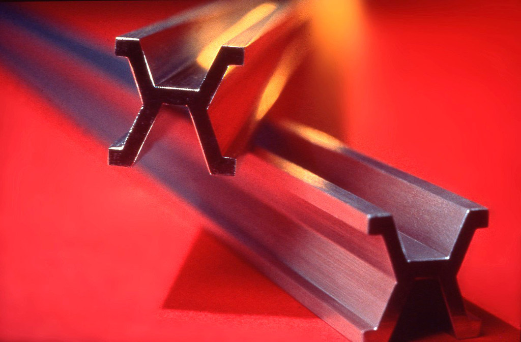

### 1. Magnitudes y unidades de medida

Las magnitudes representan lo que se mide, por ejemplo una longitud, una presión, una velocidad. Además una misma magnitud puede medirse en distintas unidades, por ejemplo una longitud puede medirse en metros o kilómetros.

Es importante conocerlas para interpretar los manuales de las máquinas y regularlas correctamente. Por ejemplo los neumáticos deben inflarse a cierta presión y es común los manuales den este valor en PSI (Libras por pulgada cuadrada), una unidad inglesa.

### 2. Algunas magnitudes muy usadas en mecánica

Casi todos los paises del mundo usan las unidades del sistema internacional (SI) como el metro, el segundo, etc. Algunos paises de habla inglesa siguen usando unidades propias como la pulgada (longitud), las libras (fuerza), etc. Nosotros seguimos al sistema internacional pero igual hay que entender algunas unidades inglesas por que los equipos importados de esos paises vienen con esas unidades.

| **Magnitud** | **Unidad SI** | **Símbolo unidad** | **Equivalencias y observaciones** |
| --- | --- | --- | --- |
| **Longitud** | metro | m | 1 km = 1000 m; 1 pulgada = 25,4 mm |
| **Tiempo** | segundo | s | 1 min = 60 s; 1 h = 3600 s |
| **Velocidad** | metro por segundo | m/s | 1 km/h = 0,27778 m/s |
| **Velocidad angular** | radian por segundo | rad/s | 1 rev/min (rpm) = 0,1047 rad/s |
| **Fuerza** | newton | N | 1 N = 1 kg·m/s² |
| **Presión** | pascal | Pa | 1 Pa = 1 N/m²; 1 bar = 100 000 Pa |
| **Par motor (torque)** | newton metro | N·m | Muy usado en motores |
| **Potencia** | watt | W | 1 hp (CV) ≈ 735,5 W (mecánica) |
| **Temperatura** | kelvin / grados Celsius | K / °C | °C = K - 273,15 |

### 4. Cálculo de velocidades

La velocidad mide cuan rápido se mueve algo, puede ser lineal o de giro (angular). Se calcula dividiendo la distancia recorrida por el tiempo empleado en recorrerla.

#### Actividad

Aprende a hacer pasaje de unidades y resuelve estos problemas:

**Velocidad lineal**

1. ¿Cuántos km son 5000 m? ¿Qué velocidad media en km/h tiene un tractor que avanzó 5000 m en una hora? ¿Por qué se usa aquí el término “velocidad media”?
2. ¿Qué velocidad media en km/h tiene un Dron que recorre una longitud de 2 km en 7 minutos?
3. Una sembradora hace su trabajo atravezando un campo de 1,5 km en 30 minutos. Esto lo hace a la ida. A la vuelta tarda 45 minutos. ¿Qué velocidad media en Km/h (kilómetros por hora) tiene la sembradora a la ida y a la vuelta? Debe explicar y mostrar las cuentas que hace y poner un texto con la respuesta.

**Velocidad angular**

4. Un motor eléctrico puede funcionar a 3000 rpm. ¿Cuántas vueltas da en una hora? ¿Cuántas vueltas da en un segundo?
5. El motor 1 gira a 2500 rpm y el motor 2 gira dando 165.000 vueltas en una hora. ¿Cuál de los motors es más rápido?
6. El eje de un motor de dos tiempos da 180.000 vueltas en una hora. ¿Cuá es la velocidad angular en “rpm” (revoluciones por minuto) de este motor? Debe explicar y mostrar las cuentas que hace y poner un texto con la respuesta.